# Calidad del servicio de internet de los estudiantes de UTEC

### Velocidad carga máxima vs Costo

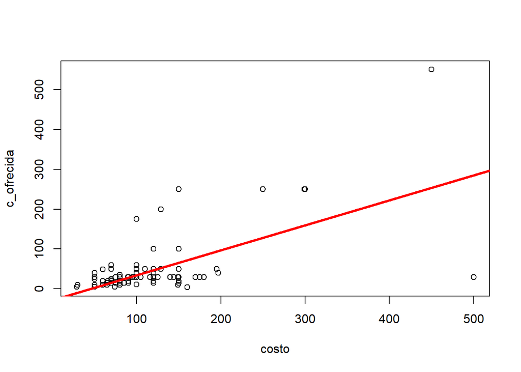

```
## Pendiente: 0.626955
```

```
## Intersección: -28.75821
```

```
## coeficiente de determinación: 0.4084964
```

```
## Coeficiente de correlación: 0.6391372
```

```
## valor-p: 6.094037e-19
```

```
## Significancia: 0.05
```

### Velocidad descarga máxima - Velocidad descarga, costo

```
##
## Call:
## lm(formula = datosUTEC$VD_ofrecida ~ datosUTEC$V_descarga + datosUTEC$Costo)
##
## Residuals:
##      Min       1Q   Median       3Q      Max
## -137.484  -17.254   -5.879   16.030  233.945
##
## Coefficients:
##                       Estimate Std. Error t value Pr(>|t|)
## (Intercept)          -15.05071    7.13653  -2.109   0.0366 *
## datosUTEC$V_descarga   0.37799    0.07663   4.932 2.13e-06 ***
## datosUTEC$Costo        0.86739    0.08333  10.409  < 2e-16 ***
## ---
## Signif. codes:  0 '***' 0.001 '**' 0.01 '*' 0.05 '.' 0.1 ' ' 1
##
## Residual standard error: 41.42 on 150 degrees of freedom
## Multiple R-squared:  0.7616, Adjusted R-squared:  0.7584
## F-statistic: 239.6 on 2 and 150 DF,  p-value: < 2.2e-16
```

Verificamos el ajuste de forma gráfica.

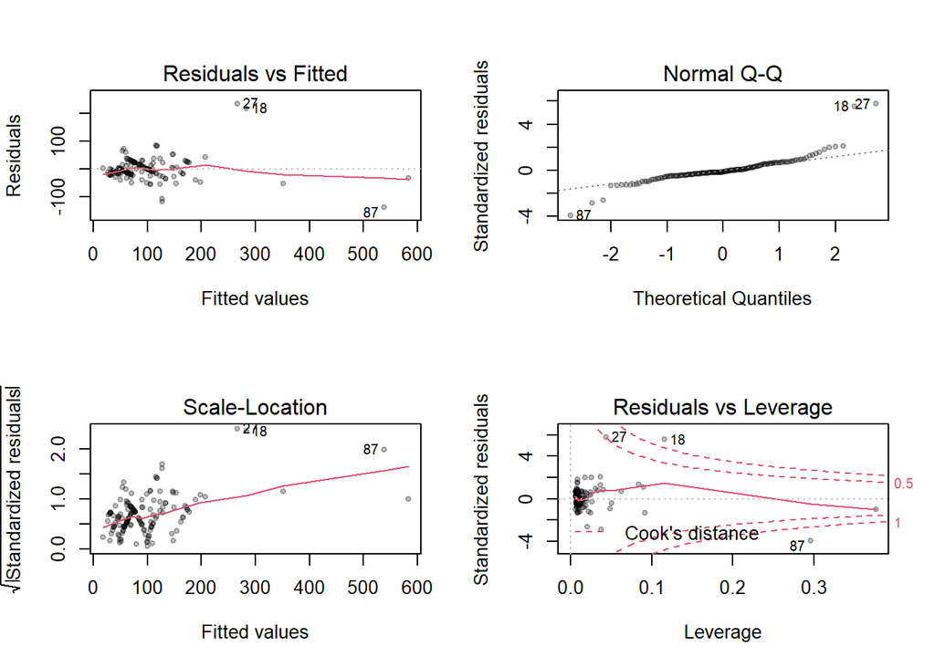

**Observaciones**

**Predicciones**

No es posible realizar predicciones significativas con el modelo.

Por ello, lo comprobaremos usando la función de ajuste.

$$y = 0.37799\cdot \text{descarga} + 0.86739 \cdot \text{costo} - 15.05071$$

Reemplazando los datos $costo = 449$ y $descarga = 240$,

obtenemos $descarga máxima = 465.125$ Mbps.

Sin embargo el resultado deberia ser al menos 600, ya que las empresas deben asegurar el 0.4 del valor. Dado que resulta poco creíble que la mayoría de las empresas no cumplan lo acordado, vemos que se trata de un modelo inadecuado.

### Porcentaje de Velocidad de Descarga Recibido (Real/Max) VS Costo

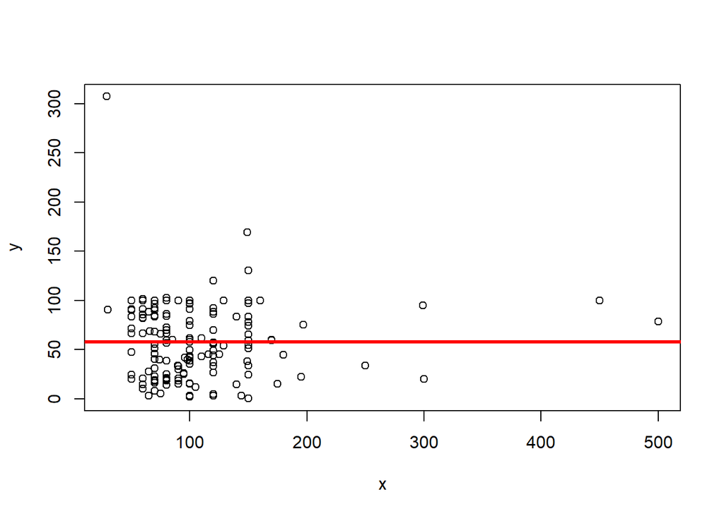

```
## Pendiente: -0.0001946312
```

```
## Intersección: 58.03152
```

```
## coeficiente de determinación: 9.407251e-08
```

```
## Coeficiente de correlación: 0.0003067124
```

```
## valor-p: 0.9969978
```

```
## Significancia: 0.05
```

Finalmente, se acepta la hipótesis nula para esta relación, puesto que, se presenta un valor-p mayor a la significancia. Además, un coeficiente de determinación muy cercano a 0.

### **Resumen de la sección**

# Variables aleatorias

A continuación se presentan modelos de variables aleatorias que eventualmente ayudarán a conseguir los objetivos proyectados por el grupo

## Distribuciones discretas

### Velocidad de carga y carga máxima

En la variable se hace uso del modelo de Bernoulli en el cúal se considera un caso exitoso si la velocidad de carga que presenta el alumno es mayor al 40% de la velocidad de carga máxima ofrecida por su distribuidora. Y como fracaso cuando la velocidad de carga no cumpla con este requerimiento mínimo.

Tambien estimaremos la precisión o error para la proporción calculada en la distribución, mediante la siguiente formula :

$$n =
N*Z^2(1-alfa/2)*p*q/(error^2*(N-1)+Z^2*p*q)$$

donde :

- **n** : Tamaño de la muestra
- **N** : Tamaño de la población
- **alfa** : Nivel de Significancia
- **Z** : Cuantil de la distribución Normal
- **p** : Proporción Poblacional(si no es conocida se asume 0.5)
- **q** : 1-p
- **Z** : Cuantil de la distribución Normal

Cabe mencionar que para las proporciones subsiguientes, también será válida esta precisión calculada, debido a que, en la formula se utiliza la proporción poblacional y si esta no es conocida (como en nuestro caso para todas nuestras proporciones), se estima en 0.5.

```
## Proporción :
```

```
## 0.7189542
```

```
## Precisión  :
```

```
## 0.006002257
```

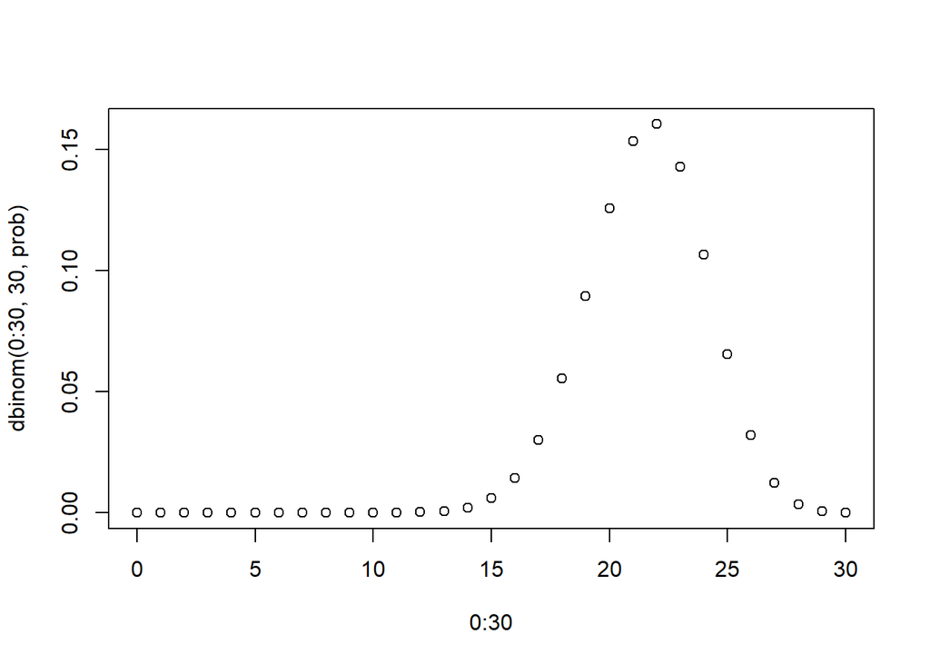

### Velocidad de descarga y descarga máxima

En la variable se hace uso del modelo de Bernoulli en el cual se considera un caso exitoso si la velocidad de descarga que presenta el alumno es mayor al 40% de la velocidad de descarga máxima ofrecida por su distribuidora. Y como fracaso cuando la velocidad de descarga no cumpla con este requerimiento mínimo.

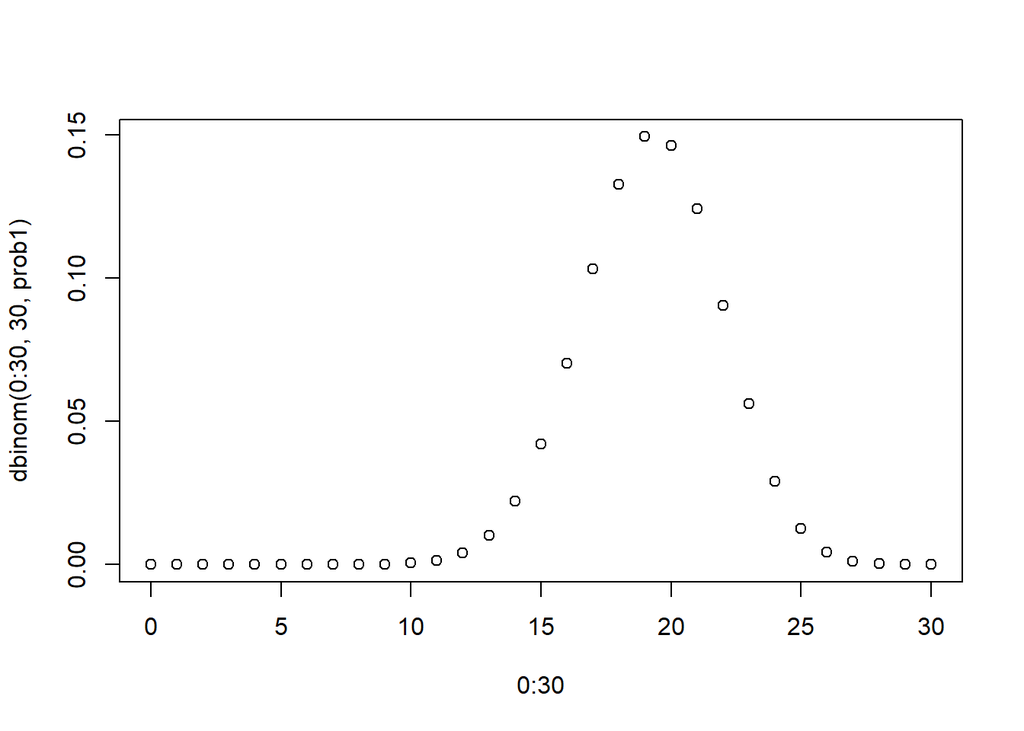

```
## Proporción :
```

[output not shown]

```
## Precisión  :
```

```
## 0.006002257
```

### Internet mediante cable

Para esta variable se hace uso del modelo Binomial en el cual se considera un caso exitoso si el alumno usa internet mediante cable, y como fracaso si no usa es tipo de internet.

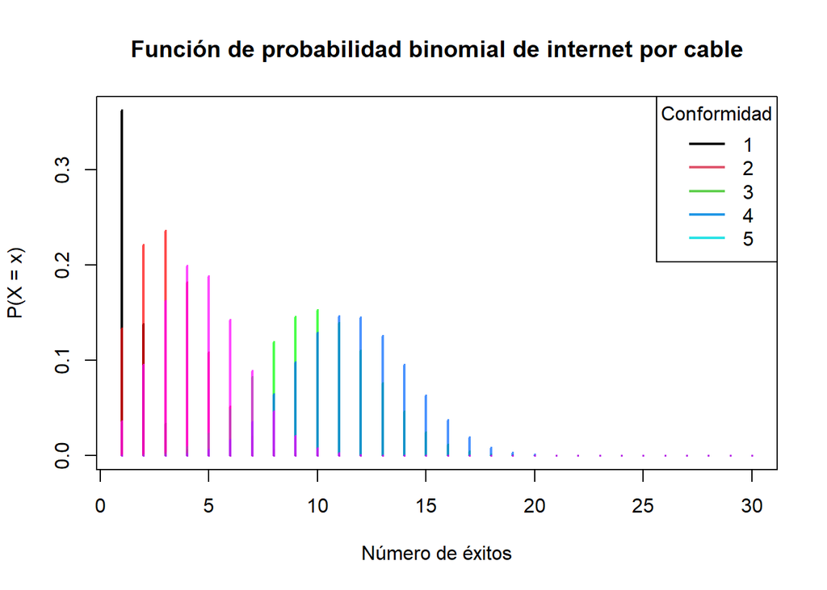

### Internet mediante WIFI

En la variable se hará uso del modelo Binomial en el cual se considera un caso exitoso si el alumno usa internet mediante WIFI, y como fracaso cuando no.

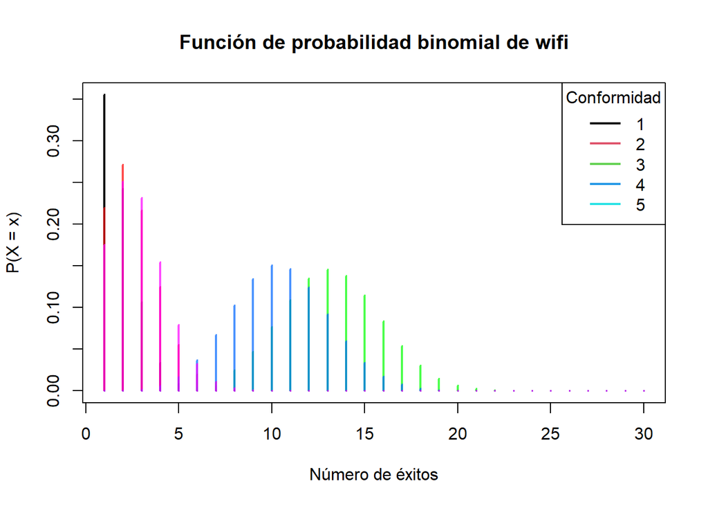

### Internet mediante datos

La variable hace uso del modelo Binomial en el cual se considera un caso exitoso si el alumno hace uso de internet mediante datos, y como fracaso cuando no.

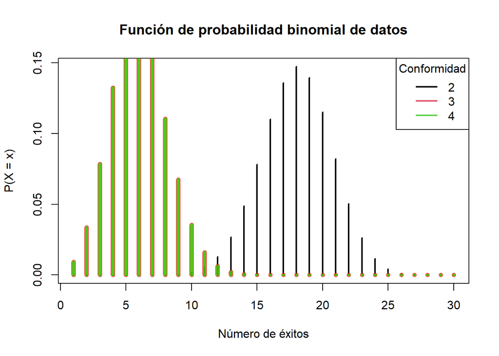

# Hipótesis

Para realizar la validación de hipótesis, emplearemos las siguientes funciones:

```r
graficaMediana<-function(datosM,alfa,tc){
  a<-ceiling(abs(tc))
  if(a<4){a=4}
  ejeX<-seq(-a,a,by=0.1)
  ejeY<-dt(ejeX,length(datosM)-1)
  plot(ejeX,ejeY,type="l",lwd=2)
  Lizq<-qt(alfa,length(datosM)-1)
  aux.x<-ejeX[ejeX<=Lizq]
  aux.y<-dt(aux.x,length(datosM)-1)
  polygon(c(-a,a,aux.x,Lizq),c(0,0,aux.y,0),col="yellow")
  #polygon(c(-Lizq,-rev(aux.x),a),c(0,rev(aux.y),0),col="yellow")
  abline(v=0)
  abline(v=tc, col=2)
}

graficaProp <- function(datos,alfa,zc){
  a<-ceiling(abs(zc))
  if(a<4){a=4}
  ejeX<-seq(-a,a,by=0.1)
  ejeY<-dnorm(ejeX)
  plot(ejeX,ejeY,typle="l",lwd=2)
  Lizq<-qnorm(alfa)
  aux.x<-ejeX[ejeX<=Lizq]
  aux.y<-dt(aux.x,length(datos))
  polygon(c(-a,a,aux.x,Lizq), c(0,0,aux.y,0),col="yellow")
  abline(v=0)
  abline(v=zc, col=2)
}

hipMedia <- function(datos,alfa,mu){
  media=mean(datos)
  desEst=sd(datos)
  var=desEst^2

  t_c=(media-mu)/(desEst/sqrt(length(datos)))

  t_=qt(alfa,length(datos)-1)
  print(paste("t: ",t_))
  print(paste("tc: ",t_c))
  if(t_c>=t_){print("H0 no se rechaza")}
  if(t_c<t_){print("H0 se rechaza")}

  alternativa="greater"
  graficaMediana(datos,alfa,t_c)

  t.test(datos,alternative = alternativa,mu=mu)
}

hipProp <- function(datos, exito, alfa, pi){
  n = length(datos)
  x = length(datos[datos==exito])
  p = x/n

  Z_c = (p - pi)/sqrt(pi*(1-pi)/n)

  Z_ = qnorm(alfa)
  print(paste("z: ", Z_))
  print(paste("zc: ", Z_c))
  if(Z_c>=Z_){print("H0 se acepta")}
  if(Z_c<Z_){print("H0 se rechaza")}

  alternativa="less"
  graficaProp(datos,alfa,Z_c)

  prop.test(x, n, p=pi, alternative=alternativa)
}
```

### Validación de la hipótesis 1

Definimos la prueba de hipótesis:

- $H_0$:  
  La velocidad de carga promedio en Lima es mayor o igual que la velocidad de carga promedio en provincia.
- $H_a$:  
  La velocidad de carga promedio en Lima es menor que la velocidad de carga promedio en provincia.

Se trabajara con significancia de 0.05

```
## [1] "t:  -1.66088144032484"
## [1] "tc:  1.09266652777807"
## [1] "H0 no se rechaza"
```

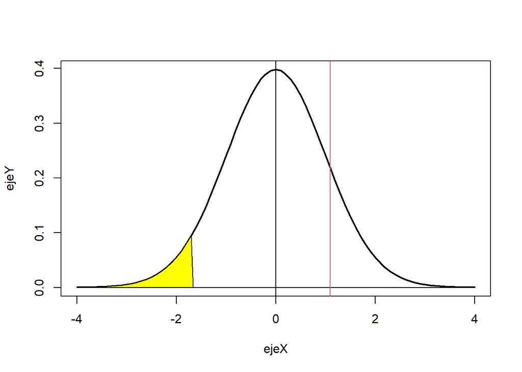

```
##
##  One Sample t-test
##
## data:  datos
## t = 1.0927, df = 96, p-value = 0.1386
## alternative hypothesis: true mean is greater than 21.28036
## 95 percent confidence interval:
##  17.69022      Inf
## sample estimates:
## mean of x
##  28.18412
```

### Validación de la hipótesis 2

Definimos la prueba de hipótesis:

- $H_0$:  
  La velocidad de descarga promedio en Lima es mayor que la velocidad de descarga promedio en provincia.
- $H_a$:  
  La velocidad de descarga promedio en Lima es menor que la velocidad de descarga promedio en provincia.

Se trabajara con significancia de 0.05

```
## [1] "t:  -1.66088144032484"
## [1] "tc:  2.73453989579282"
## [1] "H0 no se rechaza"
```

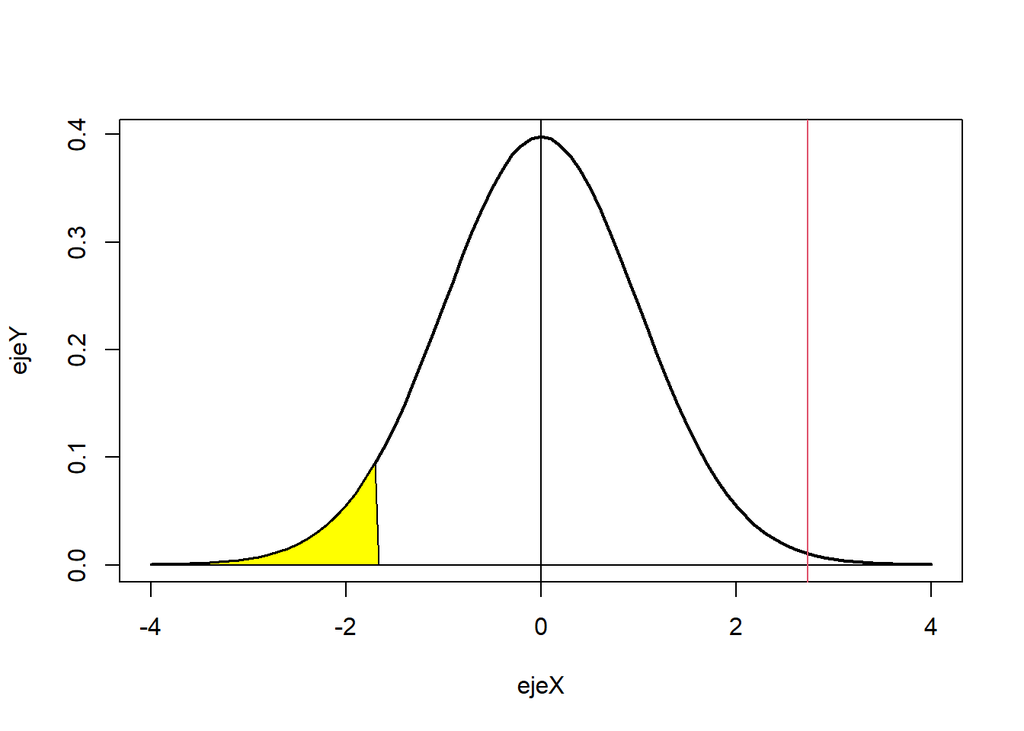

```
##
##  One Sample t-test
##
## data:  datos
## t = 2.7345, df = 96, p-value = 0.00372
## alternative hypothesis: true mean is greater than 40.80179
## 95 percent confidence interval:
##  48.51255      Inf
## sample estimates:
## mean of x
##  60.44062
```

### Validación de la hipótesis 3

Definimos la prueba de hipótesis:

- $H_0$ : $\pi \geq 0.7$
- $H_a$ : $\pi<0.7$

Se trabajará con significancia de 0.05 y $\pi$ es la proporción poblacional de la variable conformidad.

```
## [1] "z:  -1.64485362695147"
## [1] "zc:  -9.36783339524185"
## [1] "H0 se rechaza"
```

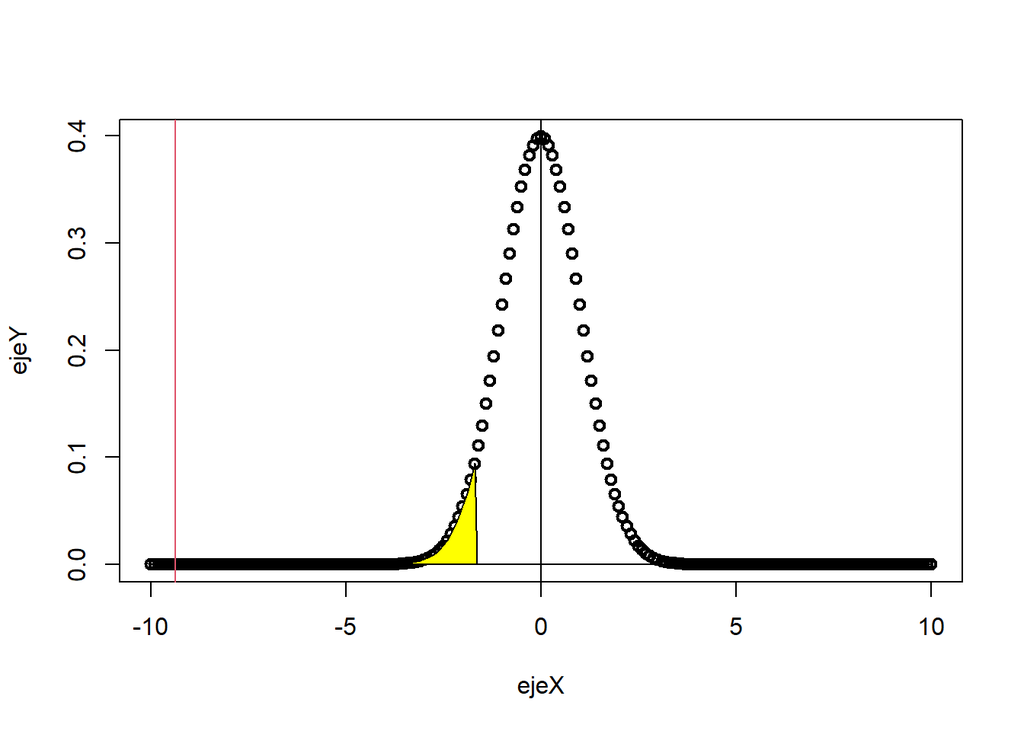

```
##
##  1-sample proportions test with continuity correction
##
## data:  x out of n, null probability pi
## X-squared = 86.111, df = 1, p-value < 2.2e-16
## alternative hypothesis: true p is less than 0.7
## 95 percent confidence interval:
##  0.0000000 0.4218819
## sample estimates:
##         p
## 0.3529412
```

### Validación de la hipótesis 4

Se trabajara con significancia de 0.05

```
## [1] "t:  -1.65494017470787"
## [1] "tc:  0"
## [1] "H0 no se rechaza"
```

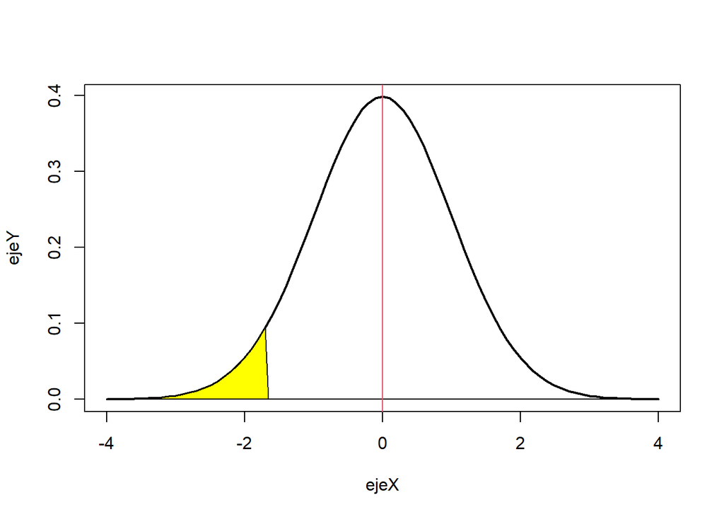

```
##
##  One Sample t-test
##
## data:  datos
## t = 0, df = 152, p-value = 0.5
## alternative hypothesis: true mean is greater than 42.95647
## 95 percent confidence interval:
##  35.72876      Inf
## sample estimates:
## mean of x
##  42.95647
```

# Intervalos de confianza y tamaño de las muestras

Se debe enfatizar el nivel de confianza o la precisión de los estimados en función de los parámetros del proyecto y los datos obtenidos, todo esto debe ir acompañado de un análisis descriptivo sólido que justifique las decisiones tomadas y visualizaciones apropiadas que refuercen estas.

En cuanto al nivel de confianza y la precisión, se decidió por escoger un nivel de confianza del 95%, es decir un nivel de significancia del 5%, esto nos ayudó a calcular para cada variable, un nivel de error o precisión. Asimismo optamos por usar la corrección de población finita.

A continuación veremos por cada variable las implicancias del nivel de confianza tomado y contrastaremos si el nivel de error es aceptable de acuerdo a la escala de valores de dicha variable.

# Velocidad de Carga

## Intevalo de confianza

Media Muestral :25.65725

Precisión :8.425777

Lo anterior nos arroja el siguiente intervalo de Confianza :

$$[17.23 , 34.08]$$

## Tamaño de la muestra

Considerando un nivel de significancia del 5% y un error de 1mbps Se puede estimar el tamaño de la muestra se debió considerar de los 3475 estudiantes de UTEC

```
## [1] 2661.131
```

Aproximadamente se debió tomar una muestra de 2662 observaciones para lograr la aproximación que consideramos representativa y adecuada.

# Velocidad de Descarga

## Intervalo de confianza

Promedio :53.25255

Precisión :10.26852

Lo anterior nos arroja el siguiente intervalo de Confianza:

$$[42.98 , 63.52]$$

## Tamaño de la muestra

Considerando un nivel de significancia del 5% y un error de 1mbps Se puede estimar el tamaño de la muestra se debió considerar de los 3475 estudiantes de UTEC

```
## [1] 2881.624
```

Aproximadamente se debió seleccionar una muestra de 2882 observaciones para lograr la aproximación que consideramos representativa y adecuada

# Costo

## Intervalo de confianza

Promedio :105.0633

Precisión :9.443203

Lo anterior nos arroja el siguiente intervalo de Confianza :

$$[95.62 , 114.5]$$

## Tamaño de la muestra

Considerando un nivel de significancia del 5% y un error de 1mbps Se puede estimar el tamaño de la muestra se debió considerar de los 3475 estudiantes de UTEC

```
## [1] 2794.569
```

Aproximadamente se debió seleccionar una muestra de 2795 observaciones para lograr la aproximación que consideramos representativa y adecuada

## Velocidad de Carga Maxima

### Intervalo de confianza

Promedio :37.11176

Precisión :9.263211

Lo anterior nos arroja el siguiente intervalo de Confianza :

$$[27.84 , 46.37]$$

## Tamaño de la muestra

Considerando un nivel de significancia del 5% y un error de 1mbps Se puede estimar el tamaño de la muestra se debió considerar de los 3475 estudiantes de UTEC

```
## [1] 2773.261
```

Aproximadamente se debió seleccionar una muestra de 2774 observaciones para lograr la aproximación que consideramos representativa y adecuada

## Velocidad de Descarga Maxima

### Intervalo de confianza

Promedio :96.20902

Precisión :13.05709

Lo anterior nos arroja el siguiente intervalo de Confianza :

$$[83.15 , 109.26]$$

## Tamaño de la muestra

Considerando un nivel de significancia del 5% y un error de 1mbps Se puede estimar el tamaño de la muestra se debió considerar de los 3475 estudiantes de UTEC

```
## [1] 3082.437
```

Aproximadamente se debió seleccionar una muestra de 3083 observaciones para lograr la aproximación que consideramos representativa y adecuada

Para determinar que la Velocidad de Carga influye en la experiencia respecto a los servicios de internet por parte de los alumnos de UTEC, observaremos lo siguiente:

```r
datosUTEC %>% group_by(Conformidad) %>% summarise(Media = mean(as.numeric(V_carga))) %>% pander()
```

| Conformidad | Media |
| --- | --- |
| 1 | 4.047 |
| 2 | 8.588 |
| 3 | 17.3 |
| 4 | 22.36 |
| 5 | 89.34 |

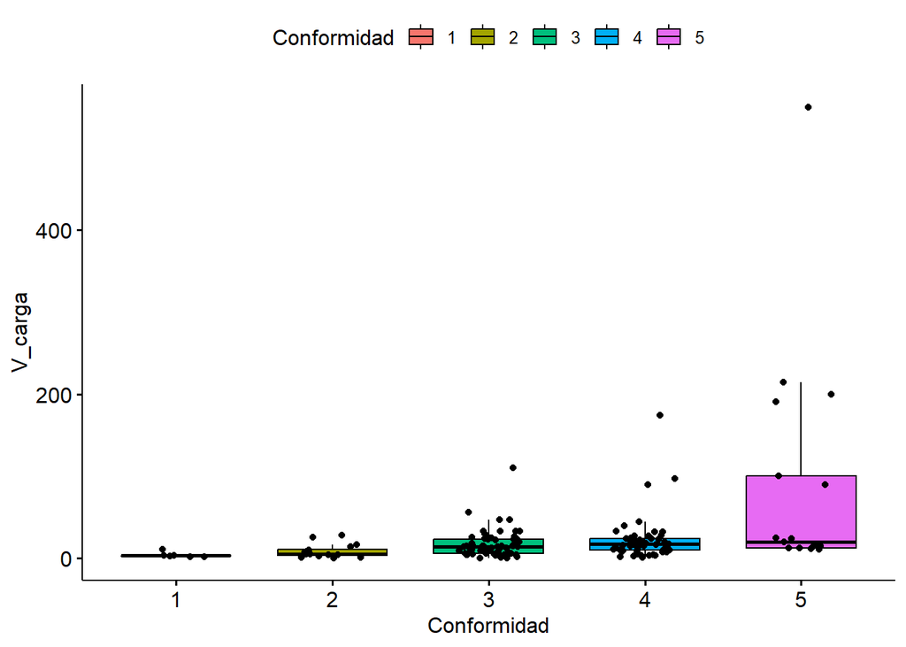

```r
datosUTEC$V_carga<-as.double(datosUTEC$V_carga)
ggboxplot(data = datosUTEC,x = "Conformidad",y = "V_carga",
                  fill = "Conformidad", add = "jitter")
```

Observamos que el descontento con el servicio de internet se manifiesta con un nivel de Conformidad menor o igual a 2, lo cual implica un promedio de velocidad de carga de 8.58 Mbps.

El siguiente paso que ya esta fuera de este estudio es efectuar un ANOVA de un factor para establecer diferencias estadisticamente significativas, esto implica ver normalidad de datos, residuos así como homocedasticidad (homogeneidad de varianzas), para determinar diferencias significativas entre los niveles de conformidad con respecto a los promedios de velocidad de carga.

Por lo pronto podemos establecer que la **velocidad de carga es un factor que influye en la experiencia respecto a los servicios de internet por parte de los alumnos de UTEC.**

# Velocidad de Descarga

Para determinar que la Velocidad de Descarga influye en la experiencia respecto a los servicios de internet por parte de los alumnos de UTEC, observaremos lo siguiente:

```r
datosUTEC %>% group_by(Conformidad) %>% summarise(Media = mean(as.numeric(V_descarga))) %>% pander()
```

| Conformidad | Media |
| --- | --- |
| 1 | 40.5 |
| 2 | 27.18 |
| 3 | 42.6 |
| 4 | 52.23 |
| 5 | 123.1 |

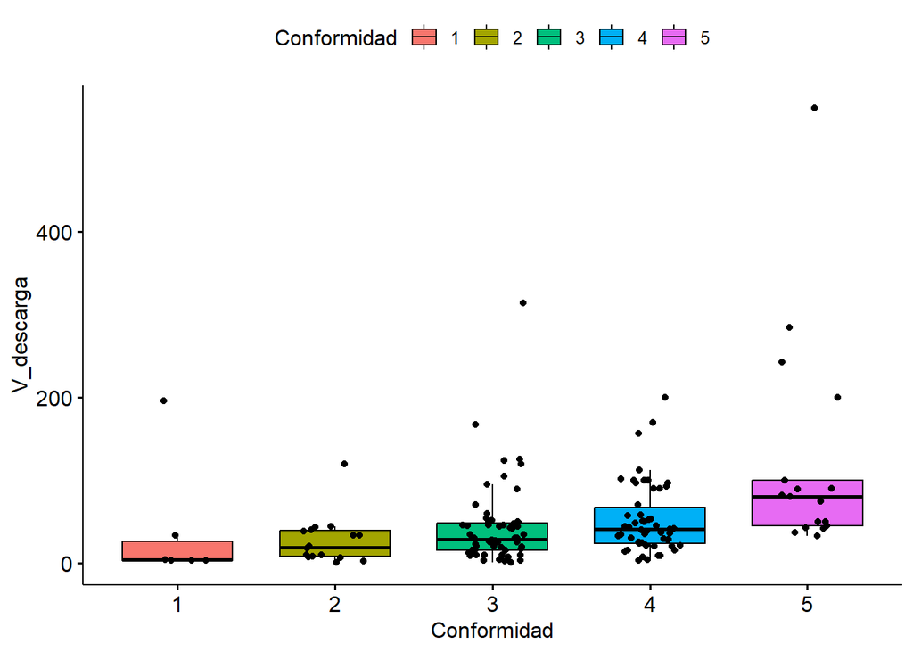

```r
datosUTEC$V_carga<-as.double(datosUTEC$V_descarga)
ggboxplot(data = datosUTEC,x = "Conformidad",y = "V_descarga",
                  fill = "Conformidad", add = "jitter")
```

# Ping

Para determinar que el Ping influye en la experiencia respecto a los servicios de internet por parte de los alumnos de UTEC, observaremos lo siguiente:

```r
datosUTEC %>% group_by(Conformidad) %>% summarise(Media = mean(as.numeric(Ping))) %>% pander()
```

| Conformidad | Media |
| --- | --- |
| 1 | 142 |
| 2 | 25.44 |
| 3 | 25.08 |
| 4 | 20.04 |
| 5 | 15.35 |

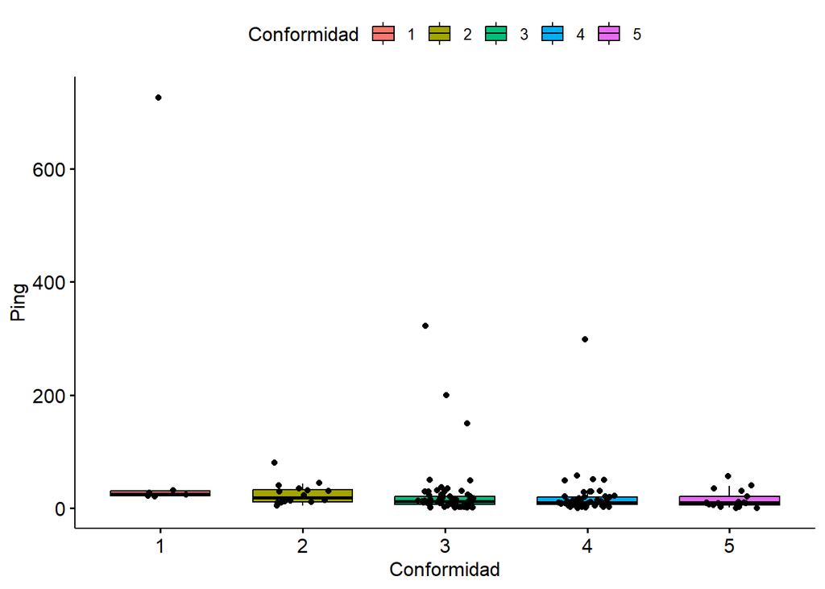

```r
datosUTEC$V_carga<-as.double(datosUTEC$Ping)
ggboxplot(data = datosUTEC,x = "Conformidad",y = "Ping",
                  fill = "Conformidad", add = "jitter")
```

Observamos que conforme mayor Ping (Mayor tiempo de reacción) existe menor nivel de satisfacción o conformidad por parte del usuario. Sin embargo, al analizar las medias de los datos y observar el bloxplot no se evidencia de manera notoria la relación con la conformidad del usuario.

Por lo pronto podemos establecer que el **Ping es un factor que no influye de manera significativa en la experiencia respecto a los servicios de internet por parte de los alumnos de UTEC.**

# Tipo de Conexion

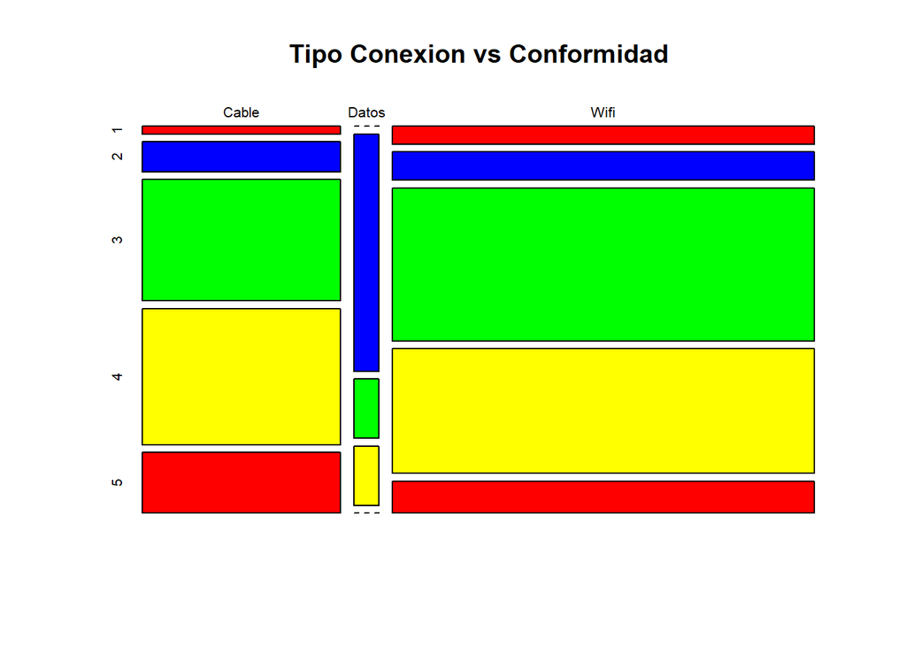

```r
mosaicplot(table(datosUTEC$Tipo_conexion,datosUTEC$Conformidad),col=c("red","blue","green","yellow"),main = "Tipo Conexion vs Conformidad")
```

Observamos que la mayoría de usuarios posee conexión Wifi y por cable, las cuales no representan una diferenciación en el nivel de conformidad. Sin embargo una minoría posee tipo de conexión :datos y estos usuarios si manifiestan en su gran mayoría descontento con el servicio.

Por tanto podemos establecer que el **El Tipo e Conexion : Datos es un factor que influye en la experiencia respecto a los servicios de internet por parte de los alumnos de UTEC.**

Conclusiones:

**Las empresas, en su mayoría, cumplen con lo ofrecido en el plan de internet que sugieren. No obstante, dependiendo del tipo de velocidad, sea de carga o descarga, más de 1/4 y 1/3 de los estudiantes mostraron que no se cumplían con estos requerimientos básicos de dichas velocidades.**

**La calidad de internet, de los estudiantes de UTEC, puede ser muy mala o muy buena evidenciando los dos extremos, de acuerdo con los valores atípicos obtenidos, tanto en velocidad e carga, descarga y ping, ya que son los principales componentes para evaluar este servicio.**